# Analysis on *We Rate Dogs*

## Summary

After cleaning the data in our 3 tables, we are ready to perform analysis on the data we got from the We Rate Dogs twitter archive. As a frame of reference, this twitter account allows people to share photos of their dogs in order to be rated on the scale of their awesomness. Because no dog is ever lame, they are all rated beyond 100%. I concentrated my analysis efforts on the data that was fetched using the Tweepy API, along with the image predictions provided by Udacity's neural network.

1. One assesment must be made to answer a question we all have. Which tweet did people favorite the most?? The answer will melt your heart...

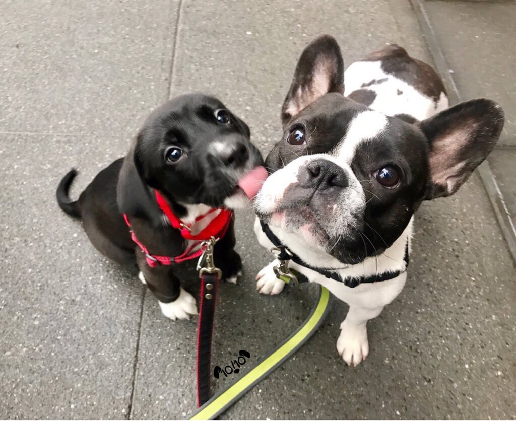

1. I then set out to analyze if there is a patter between the amout of times a tweet is favorited and retweeted.

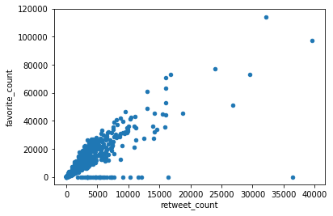

1. Finally, I decided to get more insights on the efficacy of the neural network that predicted the images for each tweet. Which were the 10 most common dog breeds tweeted per our neural network predictions?

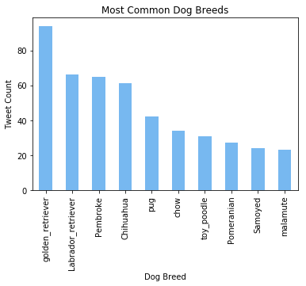

Looks like Golden Retrievers are the most popular breed of dog in WeRateDogs.

1. But which are breeds is the neural network most comfortable with? Here are the top ten along with the average confidence level percentage.

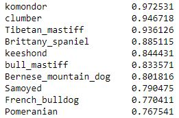

Interestingly, it looks like the algorithm feels more confident with fluffier dogs. Komondor/Tibetan Mastiff/Keeshond/Samoyed/Pomeranian are all fluffy dogs! With that said, we would need to assess the predictions based on the other photos to see if perhaps it is not confusing them.